# Topic Modeling in NLP - TfIdf - 1

One should look for what is and not what he thinks should be. (Albert Einstein)

# Tf-Idf: Topic introduction

In this part of the course, we will cover the following concepts:

- The “bag-of-words” approach and when it is used
- The need for weighting terms in a corpus
- Implementation of Tf-Idf weighting on a corpus of documents

# Module completion checklist

| Objective | Complete |
| --- | --- |
| Explain use cases for bag-of-words approach |  |
| Summarize supervised vs. unsupervised learning |  |

# The importance of word counts

- TF-IDF (term frequency-inverse document frequency) is a statistical measure that evaluates how relevant a specific word is to a document in a collection of documents
- This is done by multiplying two metrics: how many times a word appears **within a document**, and the inverse document frequency of the word **across a set of documents**
- In short, it’s about which words are really important and stand out

# The importance of word counts

- The word cloud below visually represents the words with the greatest significance in a set of documents
- What topic would you guess this set of documents is about?
- **Share your response** in the chat box

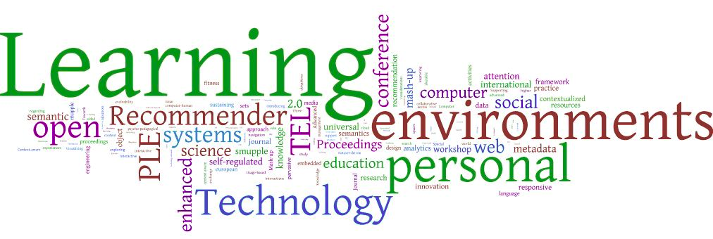

Source: [CC-BY-SA-3.0](https://commons.wikimedia.org/wiki/File:ROLE_Project_Word_Cloud.jpg)

# The math of relevance

- Algorithms need to do this with mathematical means (counting frequency) in Natural Language Processing (NLP) to make up for the lack of base knowledge that humans have to make a quick determination of relevance
- Humans also know that while certain words, like “the” and “and” are more frequent, they are never the topic of a text

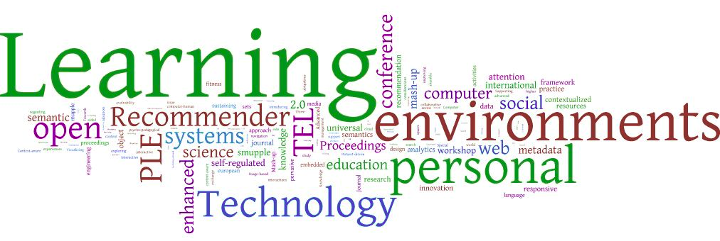

# TF-IDF: Topic Overview

- The distribution of words in a corpus and in a language is highly skewed right, which indicates that few words have very high frequencies and most words have very low counts
- A Term Frequency - Inverse Document Frequency (TF-IDF) is a famous transformation of text data used to battle the skewness of the word distribution in a corpus
- The TFIDF can then be used in the Bag-of-words analysis for text mining or other NLP tasks

# `Snippet` analysis

- In order to pre-process the data for TF-IDF, the steps to be taken are:
  - **Load** the corpus, where each ‘document’ is actually one entry in `snippet`
  - Clean the text, removing punctuation, numbers, special characters and stop words
  - *Stem* the words to their root forms
  - **Create** a Document-Term Matrix (DTM) with counts of each word recorded for each document
- Now we will build the final, optimized matrix - a weighted **T**erm **F**requency - **I**nverse **D**ocument **F**requency (TF-IDF) by
  - **Transforming** the DTM to be a weighted TF-IDF

# “Bag-of-words” analysis: use cases

- What can be done with such a seemingly *crude* approach?
- Quite a few things, actually! They include:
  - Topic modeling
  - Word and document similarity query processing
  - Word and document clustering
  - Sentiment analysis
  - Automated document summarization

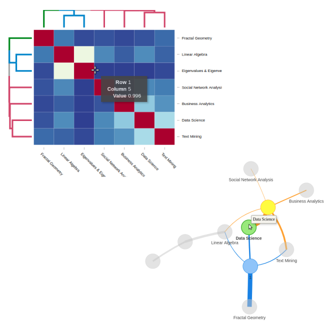

# “Bag-of-words” analysis: `snippet`

- We are going to dive deeper into one of these use cases with topic modeling
- We are going to implement a very popular method called **Latent Dirichlet Allocation (LDA)**
- This will help us understand broad topics within our corpus of documents

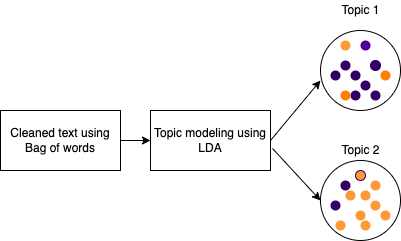

# Data exploration

- A data scientist must be able to explore data to generate a hypothesis

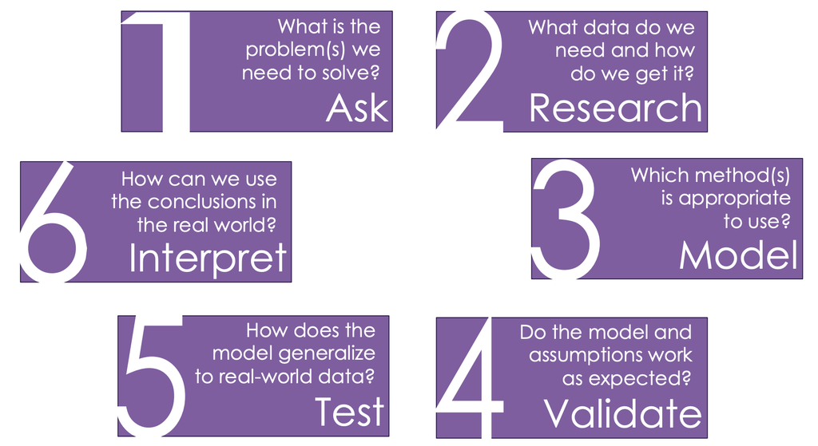

What stage of the Data Science Control Cycle (DSCC) would this goal fit into?

# DSCC: modeling

- **Have you encountered any type of text analysis models?**
- For text data, frequently the first step in model building is to use unsupervised learning

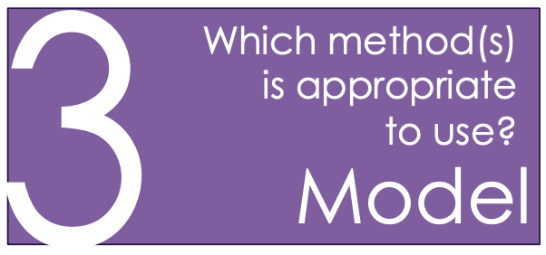

- Model, by definition, is a replica of a real thing
- Using a ship to imitate a train won’t cut it
- Select a model that suits your problem/data or **simulates the real-life situation** in the closest possible way

# Module completion checklist

| Objective | Complete |
| --- | --- |
| Explain use cases for bag-of-words approach | **✔** |
| Summarize supervised vs. unsupervised learning |  |

# What is data science?

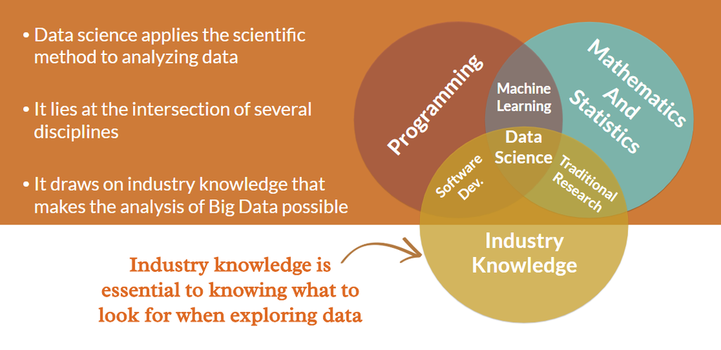

# What can data science do?

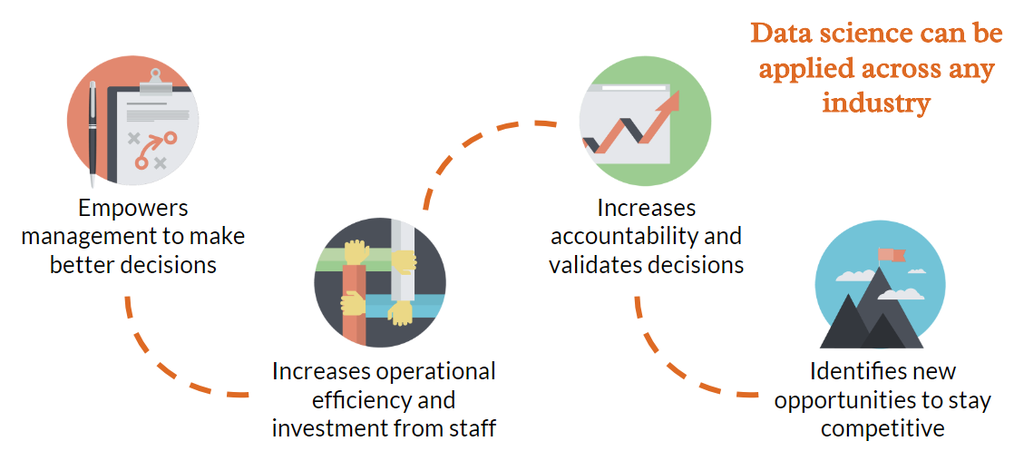

# Unsupervised vs supervised

- What types of text analysis would fall under unsupervised learning?
- What types of text analysis would fall under supervised learning?

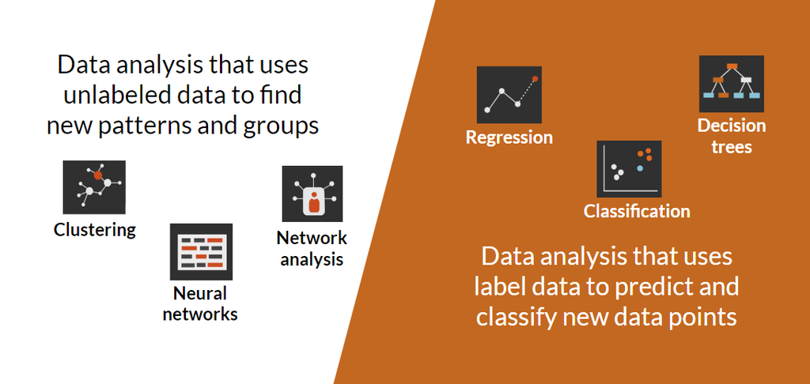

# Text analysis: unsupervised text analysis

- How does text analysis fall into the category of **unsupervised learning**?
  - In topic modeling, topics are formed from unlabeled data
  - **It involves weighing and clustering documents into “topics”**
  - **Clustering is one of the best known unsupervised techniques**
- We will learn how to **transform our DTM to a TF-IDF weighted matrix**

# Knowledge check

# Module completion checklist

| Objective | Complete |
| --- | --- |
| Explain use cases for bag-of-words approach | **✔** |
| Summarize supervised vs. unsupervised learning | **✔** |

# Congratulations on completing this module!